# Working with `data_full`

The output of a simulation, and how to handle it

This page describes what a simulation returns and shows the usual ways of handling it. Every example runs on a small database shipped with the package, so the page reproduces without running a model.

## Getting the results

### From a simulation

`run_simulations()` returns the results and stores them in `data/output`, under the `project_name` of the input configuration.

```r
config <- readconfig(input_config_file  = file.path("configuration", "config_input_threeme.R"),
                     output_config_file = file.path("configuration", "config_output_threeme.R"))

data_full <- run_simulations(configuration = config)
```

### From a simulation already run

`read_3me_output()` reads a database back from `data/output`. The results are stored as a parquet file by default, which lets the function read only what is asked for: on a full model this is the difference between a few seconds and a few minutes.

```r
## everything
data_full <- read_3me_output("my_project")

## only what is needed: much faster on a large model
macro <- read_3me_output("my_project",
                         variables = c("GDP", "CH", "I", "X", "M"),
                         scenarios = c("baseline", "ct1"),
                         years     = 2020:2050)
```

When the input configuration sets `output_saved`, the results are also stored with their sectors and commodities aggregated as the bridge of the classification says. Those versions are read with `suffix`:

| `suffix` | Database |
| --- | --- |
| `NULL` (default) | the classification of the simulation |
| `"sec"` | sectors aggregated |
| `"com"` | commodities aggregated |
| `"sec_com"` | sectors and commodities aggregated |

```r
data_agg <- read_3me_output("my_project", suffix = "sec_com")
```

### The database of this page

```r
data_full <- readRDS(system.file("extdata", "minimodel.rds", package = "ermeeth2"))
```

It comes from a small training model: five variables, a baseline and one scenario, `g`, an increase in government spending.

## What `data_full` looks like

`data_full` is a plain `data.frame` in **long format**: one line per variable, year and scenario.

```r
head(data_full)
```

| variable | year | sector | commodity | values_ref | scenario | values | index_scen |
| --- | --- | --- | --- | --- | --- | --- | --- |
| MU | 2016 | NA | NA | 0.02000 | baseline | 0.02000 | 1 |
| MU | 2016 | NA | NA | 0.02000 | g | 0.02000 | 0 |
| Y | 2016 | NA | NA | 94.23223 | baseline | 94.23223 | 1 |
| Y | 2016 | NA | NA | 94.23223 | g | 94.23223 | 0 |
| CH | 2016 | NA | NA | 55.43073 | baseline | 55.43073 | 1 |
| CH | 2016 | NA | NA | 55.43073 | g | 55.43073 | 0 |

| Column | Type | Content |
| --- | --- | --- |
| `variable` | character | Code of the variable, in upper case. |
| `year` | numeric | Period of the observation. |
| `scenario` | character | Name of the scenario, as in the input configuration. |
| `values` | numeric | Value in the scenario. |
| `values_ref` | numeric | Value in the baseline, for the same variable and year. |
| `index_scen` | numeric | 1 on the lines of the baseline, 0 on the others. |
| `sector` | character | Sector of the variable, `NA` if it has none. |
| `commodity` | character | Commodity of the variable, `NA` if it has none. |

A line is identified by `variable`, `year` and `scenario`. On the lines of the baseline, `values` and `values_ref` are equal.

Because `values_ref` sits next to `values` on every line, comparing a scenario with the baseline never needs a join.

### What is in it

```r
unique(data_full$scenario)
```

```
[1] "baseline" "g"
```

```r
unique(data_full$variable)
```

```
[1] "MU" "Y"  "CH" "I"  "G"
```

```r
range(data_full$year)
```

```
[1] 2016 2050
```

On a full model there are thousands of variables. `variables_like()` finds those whose code matches a regular expression:

```r
variables_like(data_full, "^C", view = FALSE)
```

```
[1] "CH"
```

The dictionary says what a code means:

```r
dict_labels(unique(data_full$variable))
```

```
                      MU                        Y                       CH
                "Markup"                 "Output"  "Household consumption"
                       I                        G
            "Investment" "Government expenditure"
```

```r
dict_labels(unique(data_full$variable), lang = "fr")
```

```
                        MU                          Y
           "Taux de marge"               "Production"
                        CH                          I
"Consommation des ménages"           "Investissement"
                         G
      "Dépenses publiques"
```

## Selecting

Everything here is `dplyr::filter()`.

### One scenario

```r
shock <- data_full |> filter(scenario == "g")
head(shock, 3)
```

| variable | year | sector | commodity | values_ref | scenario | values | index_scen |
| --- | --- | --- | --- | --- | --- | --- | --- |
| MU | 2016 | NA | NA | 0.02000 | g | 0.02000 | 0 |
| Y | 2016 | NA | NA | 94.23223 | g | 94.23223 | 0 |
| CH | 2016 | NA | NA | 55.43073 | g | 55.43073 | 0 |

`index_scen` is a shortcut to leave the baseline out, whatever the scenarios are called:

```r
data_full |> filter(index_scen == 0) |> distinct(scenario)
```

| scenario |
| --- |
| g |

### A set of variables

```r
activity <- data_full |> filter(variable %in% c("Y", "CH", "I"))
distinct(activity, variable)
```

| variable |
| --- |
| Y |
| CH |
| I |

### A period

```r
data_full |>
  filter(variable == "Y", scenario == "g", year %in% 2020:2024)
```

| variable | year | sector | commodity | values_ref | scenario | values | index_scen |
| --- | --- | --- | --- | --- | --- | --- | --- |
| Y | 2020 | NA | NA | 102.0000 | g | 102.0000 | 0 |
| Y | 2021 | NA | NA | 104.0400 | g | 105.4272 | 0 |
| Y | 2022 | NA | NA | 106.1208 | g | 108.6455 | 0 |
| Y | 2023 | NA | NA | 108.2432 | g | 111.7062 | 0 |
| Y | 2024 | NA | NA | 110.4081 | g | 114.6506 | 0 |

### A sector or a commodity

On a ThreeME database a sectoral variable has one code per sector, and the `sector` column holds the name of the sector. Both can be used:

```r
## the output of every sector
data_full |> filter(grepl("^Y_S", variable))

## everything about one sector
data_full |> filter(sector == "Construction")
```

## Computing

### Deviation from the baseline

By hand, since the baseline is on the same line:

```r
data_full |>
  filter(scenario == "g", variable == "Y", year %in% 2020:2024) |>
  mutate(rel_diff = values / values_ref - 1,
         abs_diff = values - values_ref)
```

| variable | year | sector | commodity | values_ref | scenario | values | index_scen | rel_diff | abs_diff |
| --- | --- | --- | --- | --- | --- | --- | --- | --- | --- |
| Y | 2020 | NA | NA | 102.0000 | g | 102.0000 | 0 | 0.0000000 | 0.000000 |
| Y | 2021 | NA | NA | 104.0400 | g | 105.4272 | 0 | 0.0133333 | 1.387200 |
| Y | 2022 | NA | NA | 106.1208 | g | 108.6455 | 0 | 0.0237908 | 2.524704 |
| Y | 2023 | NA | NA | 108.2432 | g | 111.7062 | 0 | 0.0319928 | 3.463006 |
| Y | 2024 | NA | NA | 110.4081 | g | 114.6506 | 0 | 0.0384257 | 4.242513 |

`threeme_transform()` does the same and knows the usual transformations. It adds a `value` column, with the `transformation` used and its `unit`:

```r
data_full |>
  filter(variable == "Y", year %in% 2020:2024) |>
  threeme_transform("reldiff") |>
  select(variable, year, scenario, values, values_ref, value, unit)
```

| variable | year | scenario | values | values_ref | value | unit |
| --- | --- | --- | --- | --- | --- | --- |
| Y | 2020 | g | 102.0000 | 102.0000 | 0.0000000 | % |
| Y | 2021 | g | 105.4272 | 104.0400 | 0.0133333 | % |
| Y | 2022 | g | 108.6455 | 106.1208 | 0.0237908 | % |
| Y | 2023 | g | 111.7062 | 108.2432 | 0.0319928 | % |
| Y | 2024 | g | 114.6506 | 110.4081 | 0.0384257 | % |

| id | meaning |
| --- | --- |
| level | level |
| reldiff | relative difference to the baseline |
| diff | absolute difference to the baseline |
| ppdiff | difference in percentage points |
| gr | annual growth rate |
| index100 | index (base year = 100) |

One call can mix them, with a vector named by variable. The element without a name is used for the variables that are not named:

```r
data_full |>
  filter(variable %in% c("Y", "MU"), year == 2025) |>
  threeme_transform(c(MU = "ppdiff", "reldiff")) |>
  select(variable, scenario, value, unit)
```

| variable | scenario | value | unit |
| --- | --- | --- | --- |
| MU | g | 0.0000000 | pp |
| Y | g | 0.0434712 | % |

### Growth rates

```r
data_full |>
  filter(variable == "Y", year %in% 2019:2023) |>
  threeme_transform("gr") |>
  select(variable, year, scenario, value)
```

| variable | year | scenario | value |
| --- | --- | --- | --- |
| Y | 2019 | baseline | NA |
| Y | 2019 | g | NA |
| Y | 2020 | baseline | 0.0200000 |
| Y | 2020 | g | 0.0200000 |
| Y | 2021 | baseline | 0.0200000 |
| Y | 2021 | g | 0.0336000 |
| Y | 2022 | baseline | 0.0200000 |
| Y | 2022 | g | 0.0305263 |
| Y | 2023 | baseline | 0.0200000 |
| Y | 2023 | g | 0.0281716 |

By hand, the series has to be grouped and sorted first:

```r
data_full |>
  filter(variable == "Y") |>
  group_by(variable, scenario) |>
  arrange(year, .by_group = TRUE) |>
  mutate(growth = values / lag(values) - 1) |>
  ungroup() |>
  filter(year %in% 2020:2022)
```

| variable | year | sector | commodity | values_ref | scenario | values | index_scen | growth |
| --- | --- | --- | --- | --- | --- | --- | --- | --- |
| Y | 2020 | NA | NA | 102.0000 | baseline | 102.0000 | 1 | 0.0200000 |
| Y | 2021 | NA | NA | 104.0400 | baseline | 104.0400 | 1 | 0.0200000 |
| Y | 2022 | NA | NA | 106.1208 | baseline | 106.1208 | 1 | 0.0200000 |
| Y | 2020 | NA | NA | 102.0000 | g | 102.0000 | 0 | 0.0200000 |
| Y | 2021 | NA | NA | 104.0400 | g | 105.4272 | 0 | 0.0336000 |
| Y | 2022 | NA | NA | 106.1208 | g | 108.6455 | 0 | 0.0305263 |

### A new variable from existing ones

A ratio, a sum or a share needs the variables side by side. The steps are always the same: keep the variables, put them in columns, compute, and put the result back in lines so that it stacks under `data_full`.

`values` and `values_ref` are both carried along, so the new variable has its own baseline and works with everything on this page.

```r
share <- data_full |>
  filter(variable %in% c("CH", "Y")) |>
  select(variable, year, scenario, index_scen, values, values_ref) |>
  ## one column per variable, for the scenario and for the baseline
  pivot_wider(names_from = variable, values_from = c(values, values_ref)) |>
  ## the share of consumption in output
  mutate(values     = values_CH / values_Y,
         values_ref = values_ref_CH / values_ref_Y,
         variable   = "CH_SHARE") |>
  select(variable, year, scenario, index_scen, values, values_ref)

data_plus <- bind_rows(data_full, share)

data_plus |> filter(variable == "CH_SHARE", year == 2025)
```

| variable | year | sector | commodity | values_ref | scenario | values | index_scen |
| --- | --- | --- | --- | --- | --- | --- | --- |
| CH_SHARE | 2025 | NA | NA | 0.5882353 | baseline | 0.5882353 | 1 |
| CH_SHARE | 2025 | NA | NA | 0.5882353 | g | 0.5853910 | 0 |

The new variable is a share: its deviation is read in points. `value` is in the unit of the variable, so -0.0077 on a share is -0.77 point.

```r
data_plus |>
  filter(variable == "CH_SHARE", year %in% c(2021, 2025, 2030)) |>
  threeme_transform("ppdiff") |>
  select(variable, year, scenario, value, unit)
```

| variable | year | scenario | value | unit |
| --- | --- | --- | --- | --- |
| CH_SHARE | 2021 | g | -0.0077399 | pp |
| CH_SHARE | 2025 | g | -0.0028443 | pp |
| CH_SHARE | 2030 | g | -0.0008338 | pp |

### A sum over sectors or commodities

On a ThreeME database, the lines of the sectors are summed after a `group_by()` that leaves the sector out:

```r
data_full |>
  filter(grepl("^EMS_S", variable)) |>
  group_by(year, scenario, index_scen) |>
  summarise(values = sum(values), values_ref = sum(values_ref), .groups = "drop") |>
  mutate(variable = "EMS_SECTORS")
```

A sum is only right for quantities. Prices and rates need a weighted mean: this is what the aggregation rules of the package hold, and what the `sec`, `com` and `sec_com` databases apply.

## From long to wide, and back

A table with one column per variable is easier to read, to export, and to compute on.

```r
wide <- data_full |>
  filter(scenario == "g") |>
  select(year, variable, values) |>
  pivot_wider(names_from = variable, values_from = values)

head(wide, 4)
```

| year | MU | Y | CH | I | G |
| --- | --- | --- | --- | --- | --- |
| 2016 | 0.02 | 94.23223 | 55.43073 | 23.55806 | 15.24345 |
| 2017 | 0.02 | 96.11688 | 56.53934 | 24.02922 | 15.54832 |
| 2018 | 0.02 | 98.03922 | 57.67013 | 24.50980 | 15.85928 |
| 2019 | 0.02 | 100.00000 | 58.82353 | 25.00000 | 16.17647 |

One column per scenario, to compare them:

```r
data_full |>
  filter(variable == "Y", year %in% 2020:2023) |>
  select(year, scenario, values) |>
  pivot_wider(names_from = scenario, values_from = values)
```

| year | baseline | g |
| --- | --- | --- |
| 2020 | 102.0000 | 102.0000 |
| 2021 | 104.0400 | 105.4272 |
| 2022 | 106.1208 | 108.6455 |
| 2023 | 108.2432 | 111.7062 |

And back to one line per variable:

```r
wide |>
  pivot_longer(-year, names_to = "variable", values_to = "values") |>
  head(4)
```

| year | variable | values |
| --- | --- | --- |
| 2016 | MU | 0.02000 |
| 2016 | Y | 94.23223 |
| 2016 | CH | 55.43073 |
| 2016 | I | 23.55806 |

## Showing

### A plot

`simple_plot()` takes `data_full` as it is. The labels come from the dictionary.

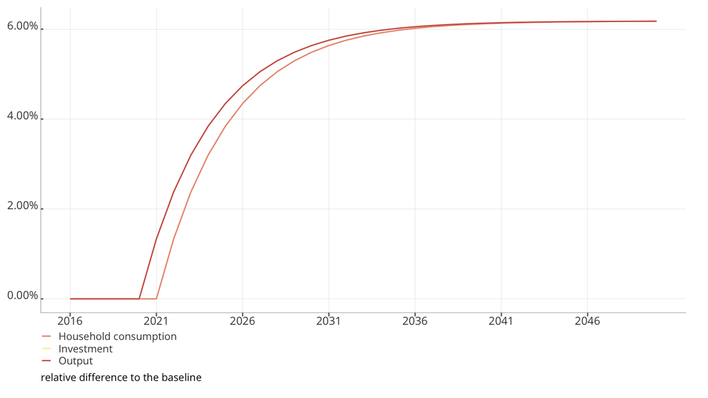

Figure 1: Deviation from the baseline

```r
simple_plot(data_full, c("Y", "CH", "I"))
```

The long format is also what `ggplot2` expects, for a plot of your own:

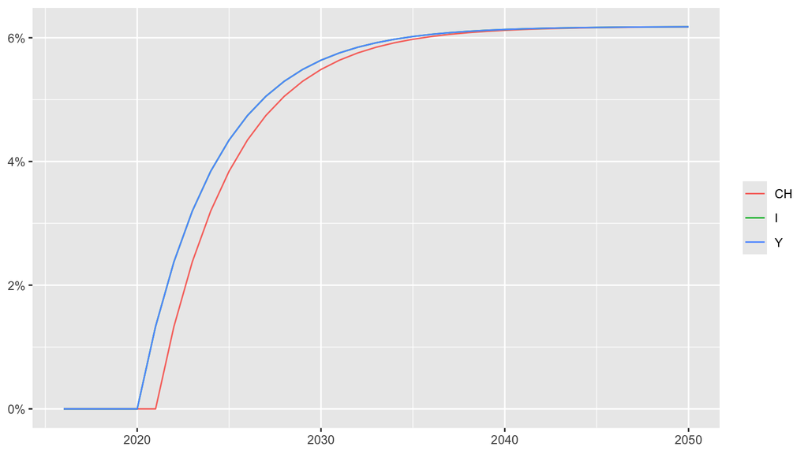

Figure 2: The same data, with ggplot2

```r
data_full |>
  filter(variable %in% c("Y", "CH", "I"), scenario == "g") |>
  ggplot(aes(x = year, y = values / values_ref - 1, colour = variable)) +
  geom_line() +
  scale_y_continuous(labels = scales::percent) +
  labs(x = NULL, y = NULL, colour = NULL)
```

### A table

```r
table_3me(data_full,
          variables = list(Activity = c("Y", "CH", "I"), Margins = "MU"),
          transformation = c(MU = "ppdiff", "reldiff"))
```

Table 1

|  |  | g t | g t + 1 | g t + 2 | g t + 5 | g t + 10 | g Long term |
| --- | --- | --- | --- | --- | --- | --- | --- |
| Activity |  |  |  |  |  |  |  |
| Output | % | 1.33 | 2.38 | 3.20 | 4.74 | 5.75 | 6.18 |
| Consumption | % | 0.00 | 1.33 | 2.38 | 4.35 | 5.64 | 6.18 |
| Investment | % | 1.33 | 2.38 | 3.20 | 4.74 | 5.75 | 6.18 |
| Margins |  |  |  |  |  |  |  |
| Markup | pp | 0.00 | 0.00 | 0.00 | 0.00 | 0.00 | 0.00 |

pp : difference in percentage points, % : relative difference to the baseline

See Graphs and tables with ermeeth2 for what these two functions can do.

## Saving

```r
## as the simulations do: data/output/my_project.parquet
save_3me_output(data_plus, "my_project")

## a spreadsheet, one column per variable
data_full |>
  filter(scenario == "g") |>
  select(year, variable, values) |>
  pivot_wider(names_from = variable, values_from = values) |>
  write.csv("results_g.csv", row.names = FALSE)
```